# Optimización de hiperparámetros

Nicolás Álvarez

2023-04-26

```r
library(tensorflow)
library(keras)
library(tidyverse)
library(tidymodels)
```

# PRIMER EJEMPLO

## Preparamos los datos

```r
dataset<-read.table('auto-mpg.data',header=T,sep='')
datos<-dataset[,c(1,5)]
colnames(datos)<-c("Peso","Consumo")
datos[,1]<-1/datos[,1]

summary(datos)
```

```
##       Peso            Consumo
##  Min.   :0.02146   Min.   :1613
##  1st Qu.:0.03448   1st Qu.:2223
##  Median :0.04348   Median :2800
##  Mean   :0.04765   Mean   :2969
##  3rd Qu.:0.05714   3rd Qu.:3609
##  Max.   :0.11111   Max.   :5140
```

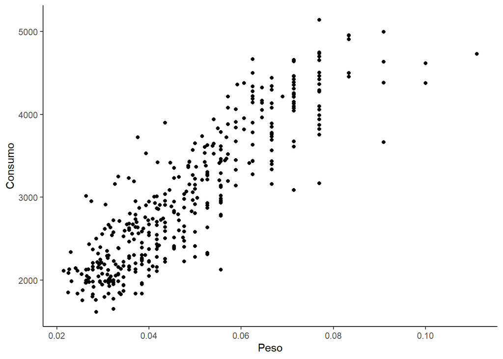

```r
ggplot() +
  geom_point(data = datos, aes(x = Peso, y = Consumo))+
  theme_classic()
```

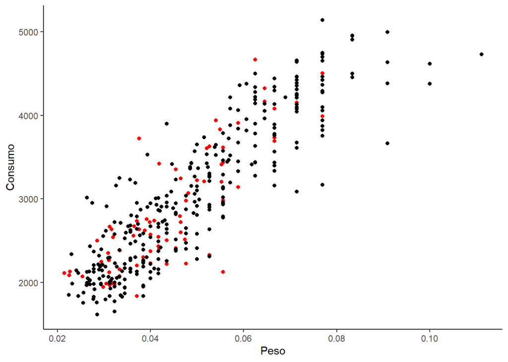

```r
split <- initial_split(datos, 0.8)
datos_train <- training(split)
datos_test <- testing(split)

ggplot() +
  geom_point(data = datos_test, aes(x = Peso, y = Consumo), color = "red") +
  geom_point(data = datos_train, aes(x = Peso, y = Consumo))+
  theme_classic()
```

## Creamos y entrenamos la Red Neuronal

Empezamos creando un modelo simple (MLP) secuencialmente, i.e., definiendo capa por capa. Antes, preparamos la capa de normalización:

```r
normalizer <- layer_normalization(input_shape = shape(1), axis = NULL)
normalizer %>% adapt(matrix(datos_train[,1]))

modelo1 <- keras_model_sequential() %>%
  normalizer() %>%
  layer_dense(units = 3) %>%
  layer_dense(units = 1)


summary(modelo1) # Informacion general
```

```
## Model: "sequential"
## ________________________________________________________________________________
##  Layer (type)                  Output Shape               Param #    Trainable
## ================================================================================
##  normalization (Normalization)  (None, 1)                 3          Y
##  dense_1 (Dense)               (None, 3)                  6          Y
##  dense (Dense)                 (None, 1)                  4          Y
## ================================================================================
## Total params: 13
## Trainable params: 10
## Non-trainable params: 3
## ________________________________________________________________________________
```

Podemos ver que ya podemos predecir valores de la variable respuesta *Consumo* aunque son erróneos, aún no hemos entrenado nuestro modelo.

```r
predict(modelo1, datos_train[1:5,1])
```

```
##            [,1]
## [1,] -0.4763303
## [2,]  0.8462191
## [3,] -0.4231923
## [4,]  0.4400074
## [5,] -0.5874690
```

Compilamos el modelo. Utilizaremos el optimizador **adam** (*Adam is an optimization algorithm that can be used instead of the classical stochastic gradient descent procedure to update network weights iterative based in training data*)

```r
modelo1 %>% compile(
  optimizer = optimizer_adam(learning_rate = 0.1),
  loss = 'mean_absolute_error'
)
```

Finalmente, podemos pasar a entrenar el modelo con los datos de entrenamiento (*datos_train*) que hemos preparado antes. Además, aportamos los datos de validación (*datos_test*), que no se usan como tal en el entreno sino para evaluar la función de pérdida (en este caso, el error medio absoluto (ver arriba)).

Obtenemos la gráfica de pérdida (*loss*) frente a los pasos (*epoch*). También el valor de la función de pérdida en el último paso: *val_loss* es sobre los datos de validación y *loss* sobre los datos de entrenamiento.

```r
history <- modelo1 %>% fit(
  as.matrix(datos_train[,1]),
  as.matrix(datos_train[,2]),
  epochs = 100,
  verbose = 0,
  validation_data=datos_test
)

history
```

```
##
## Final epoch (plot to see history):
##     loss: 312.8
## val_loss: 304.7
```

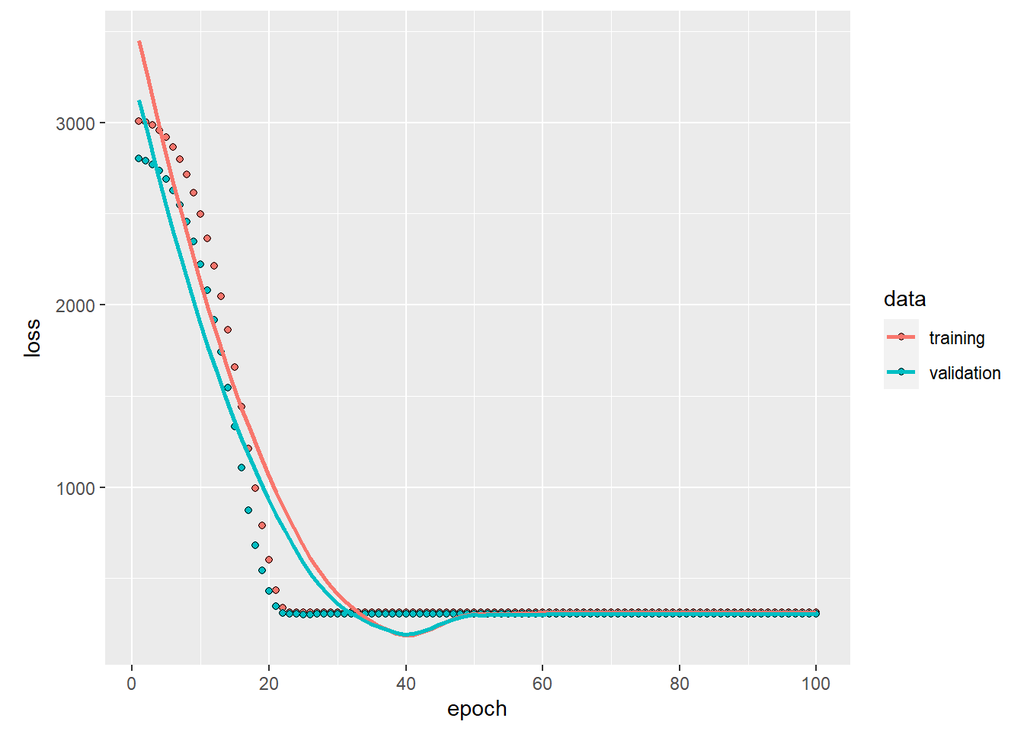

```r
plot(history)
```